# Investigating Customers Purchasing Patterns

Investigating Customer Buying Patterns and Demographics

EZEIGBOKWE BLESSING

2026-01-06

# loading required library.

# Introduction

This project is to investigate Blackwell E-commerce customers transaction data collected from recent online and in-store sales and infer any insights about customer purchasing patterns between on-line and in-store mode of purchase. The data was given by Blackwell’s company. # Objectives The goal of this project is to know the following;- 1. Do customers in different regions spend more per transactions? 2. Are there any relationship between number of items and amount spent? 3. Are there differences in the age of a customer between regions 4. can we predict the age of a customer in a region based on other demographic data. 5. Martins hypothesis needs to be investigated;is there any correlation between age of a customer and if the transactions was made online or in stores? 6. Do any other factor predict if other factors predict if a customer will buy online or in store. 7. predict the region of a customer using other demographic data.

# Methodology

1.*Data Mining:* Exploratory analysis to discover patterns 2.*Statistical Testing:* correlation analysis 3.*Machine Learning:* Predictive modeling

# data description

the dataset contains 80000 observations records with 5 variables: purchase mode, age, items, transaction amount and region. The data includes both online and in-store purchases. ## loading the dataset

## summary of dataset

```
##   purchase.mode age items  amount region
## 1             0  37     4  281.03      2
## 2             0  35     2  219.51      2
## 3             1  45     3 1525.70      4
## 4             1  46     3  715.25      3
## 5             1  33     4 1937.50      1
## 6             0  24     3 1314.20      4
```

```
##       purchase.mode age items  amount region
## 79995             0  22     1  698.54      4
## 79996             1  71     3  558.82      1
## 79997             0  59     7 1932.00      3
## 79998             0  54     1  414.16      2
## 79999             1  49     4  335.32      1
## 80000             1  30     1  527.12      3
```

```
## 'data.frame':    80000 obs. of  5 variables:
##  $ purchase.mode: int  0 0 1 1 1 0 0 1 1 1 ...
##  $ age          : int  37 35 45 46 33 24 43 66 51 47 ...
##  $ items        : int  4 2 3 3 4 3 6 5 5 3 ...
##  $ amount       : num  281 220 1526 715 1938 ...
##  $ region       : int  2 2 4 3 1 4 2 3 1 1 ...
```

```
##  purchase.mode      age            items           amount
##  Min.   :0.0   Min.   :18.00   Min.   :1.000   Min.   :   5.005
##  1st Qu.:0.0   1st Qu.:33.00   1st Qu.:3.000   1st Qu.: 285.140
##  Median :0.5   Median :45.00   Median :4.000   Median : 582.315
##  Mean   :0.5   Mean   :45.76   Mean   :4.505   Mean   : 835.920
##  3rd Qu.:1.0   3rd Qu.:56.00   3rd Qu.:6.000   3rd Qu.:1233.700
##  Max.   :1.0   Max.   :85.00   Max.   :8.000   Max.   :3000.000
##      region
##  Min.   :1.000
##  1st Qu.:2.000
##  Median :3.000
##  Mean   :2.675
##  3rd Qu.:4.000
##  Max.   :4.000
```

# Data preprocessing

## Checking out for Duplicates

```
## [1] 21
```

I checked the dataset and observed there are 21 duplicates ## Remove Duplicates I used the Distinct Function to remove the duplicates

Duplicate records were removed to avoid repeated identical transactions that could bias summary statistics and model training. ## Checking out for missing values

```
## [1] 0
```

I checked the dataset and observed there are no missing values

## Identifyin outliers

## Boxplot for age

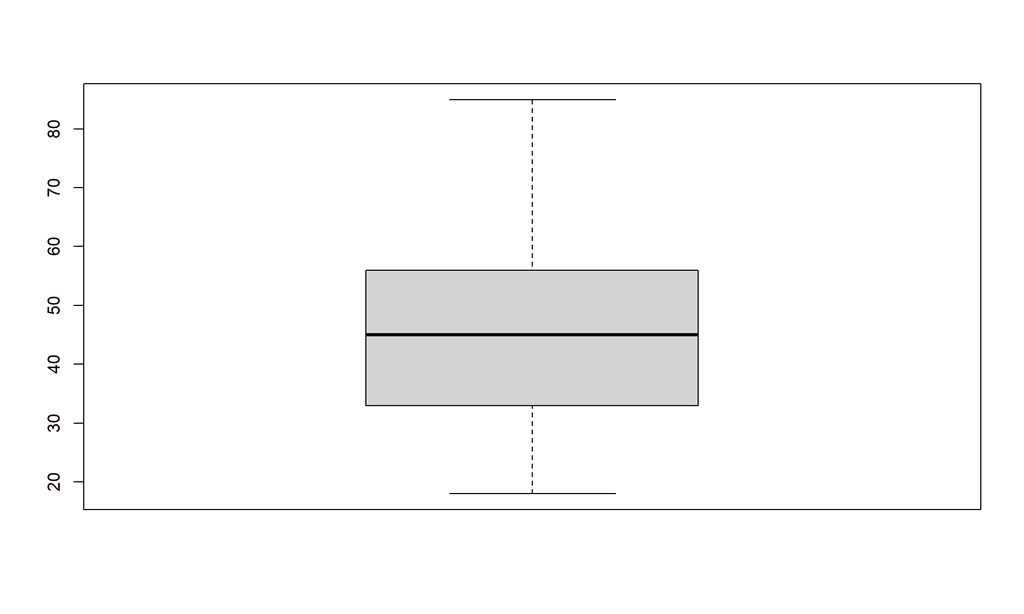

I observed there are no outliers for age. ## Boxplot for items

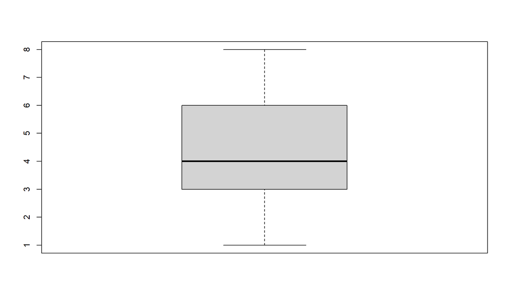

I observed there are no outliers for items. ## Boxplot for amount

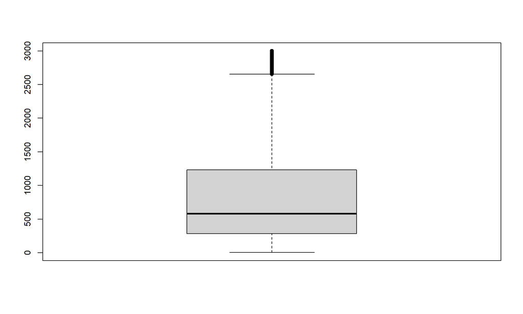

Outliers in transaction amount were retained because high-value purchases represent genuine business behavior and removing them could distort revenue analysis. ## Data Transformation

## Mapping for catergorical variables

This is to map the catergorical variables. 0,1 = online and in-store. 1,2,3,4 = north, south, east and west.

## feature engineering

we created a new feature(age range) to help us classify age into different groups. the above code also help us convert the numerical variable “age” to a categorical variable “age-range” (Discretization).

To improve interpretability, age was transformed into three categories:Adult, middle-age and elderly. This allows easier comparison of customer behavior across age groups.

```
##    purchase.mode age items    amount region  age_range
## 1         online  37     4  281.0300  South      Adult
## 2         online  35     2  219.5100  South      Adult
## 3       in-store  45     3 1525.7000   West Middle-Age
## 4       in-store  46     3  715.2500   East Middle-Age
## 5       in-store  33     4 1937.5000  North      Adult
## 6         online  24     3 1314.2000   West      Adult
## 7         online  43     6    8.5472  South Middle-Age
## 8       in-store  66     5  819.9800   East    Elderly
## 9       in-store  51     5  908.3100  North Middle-Age
## 10      in-store  47     3  767.5400  North Middle-Age
```

# Question 1: Regional Spending Patterns

*Research Question:* Do customers in different regions spend more per transaction? Which regions spend the most/least?

*Approach:* - Visualize spending distributions

# Exploratory Data analysis(EDA)

## univariate analysis

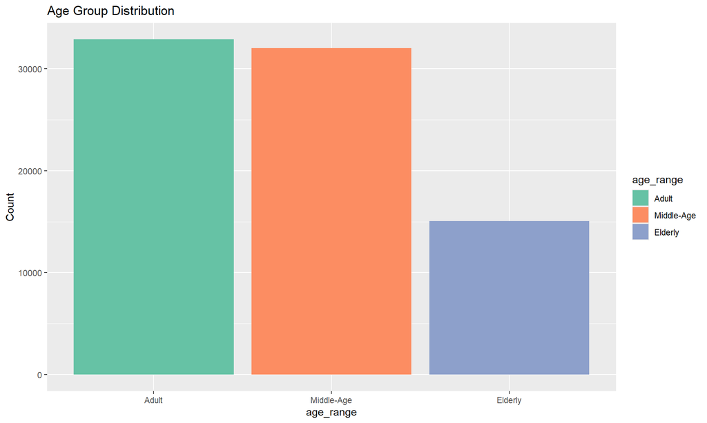

```
##   region   amount
## 1  North 11917620
## 2  South  5040442
## 3   East 16523453
## 4   West 33366990
```

## Transaction count per region

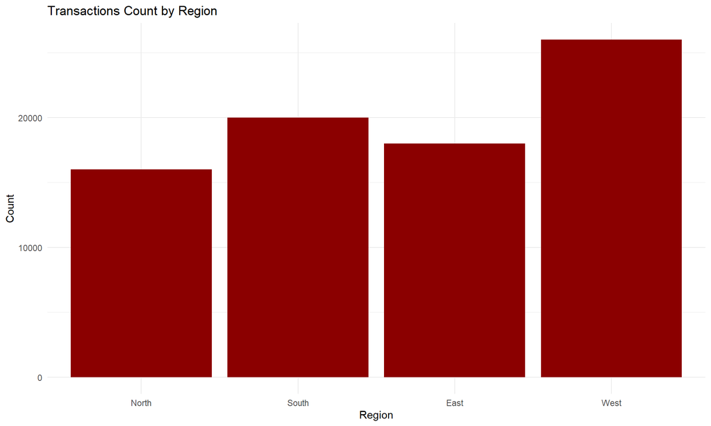

## Bivariate analysis

## Amount per region

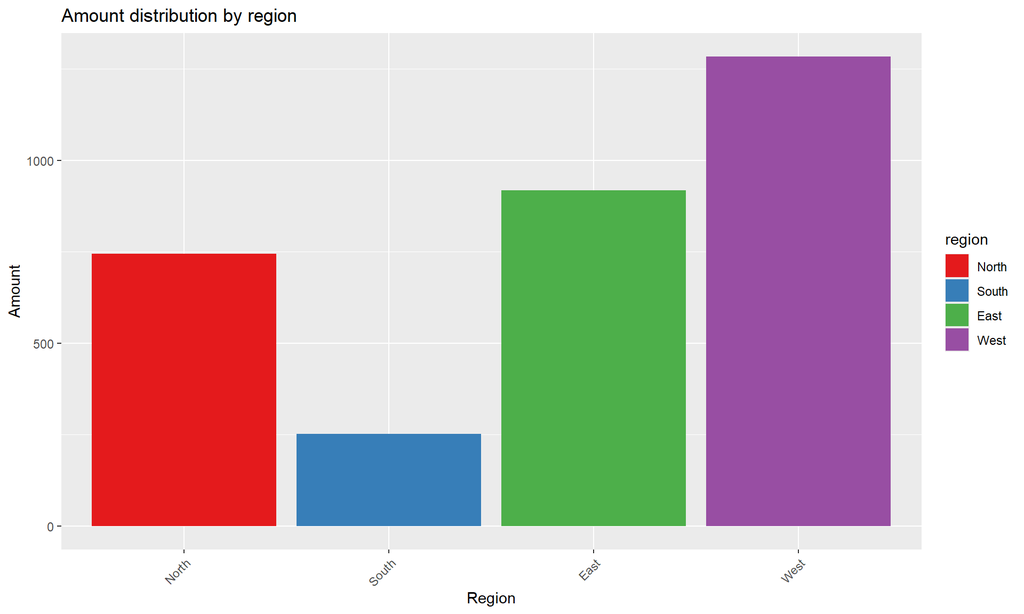

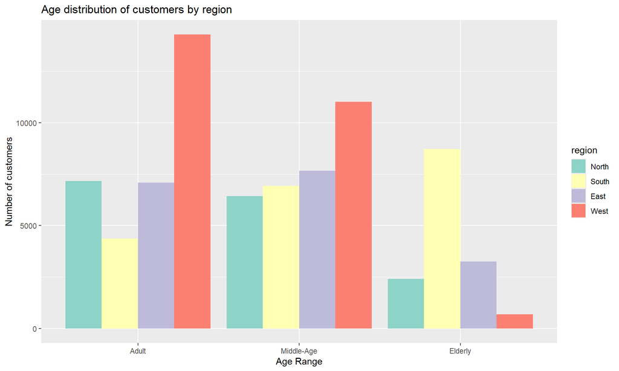

## Key Findings

Customers in different regions exhibit differences in spending behavior. The West region recorded the highest number of transactions and the highest average transaction amount, followed by the East and North regions, while the South region recorded the lowest average spending per transaction. This indicates that customers in the West contribute the most revenue per transaction, while customers in the South contribute the least. Therefore, regional location influences customer spending behavior.

# Question 2: Items vs Amount Relationship

*Research Question:* Is there a relationship between number of items purchased and amount spent?

*Approach:*

- Column Chart - Visual relationship between total amount and item

```
## # A tibble: 8 × 3
##   items total_amount Count
##   <int>        <dbl> <int>
## 1     1     4703965.  5699
## 2     2     9557061. 11284
## 3     3     9609120. 11486
## 4     4     9618610. 11594
## 5     5     9368027. 11233
## 6     6     9622197. 11519
## 7     7     9442385. 11376
## 8     8     4927143.  5788
```

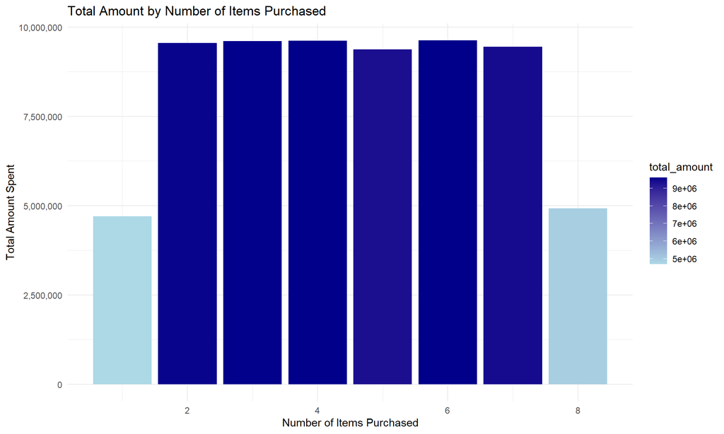

## Key Findings

The analysis of total transaction amounts by number of items showed higher total amounts for some item categories, this was due to a higher volume of transactions rather than increased spending per transaction. Therefore, purchasing more items does not necessarily lead to higher transaction spending. Customers may purchase fewer expensive items or many low-cost items, resulting in similar spending levels across item counts.

# Question 3: Age vs Region Relationship

*Research Question:* Is there a differences in the age of a customer between region?

*Approach:*

- Bar Chart - Visual relationship between Age and Region.

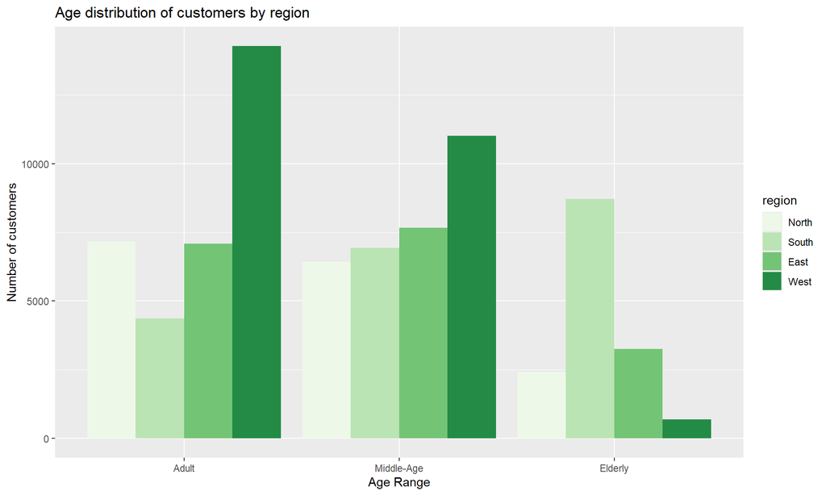

# Question 4: can we Predict the age of a customer in a region based on other demographic data?

## Predictive Modeling Approach

*Goal:* Build models to predict customer age

*Methodology:* 1. *Feature Selection Analysis* - Identify which features predict age 2. *Model Training* - Train 3 different algorithms with selected features 3. *Model Comparison* - Select the best performing model

# Feature Selection Analysis

## variable importance(feature importance)

```
##                  %IncMSE IncNodePurity
## purchase.mode 47.0155984     549522.20
## items          0.5461391       8410.33
## amount        36.7881566    1322562.43
## region        41.5921362    1566598.65
```

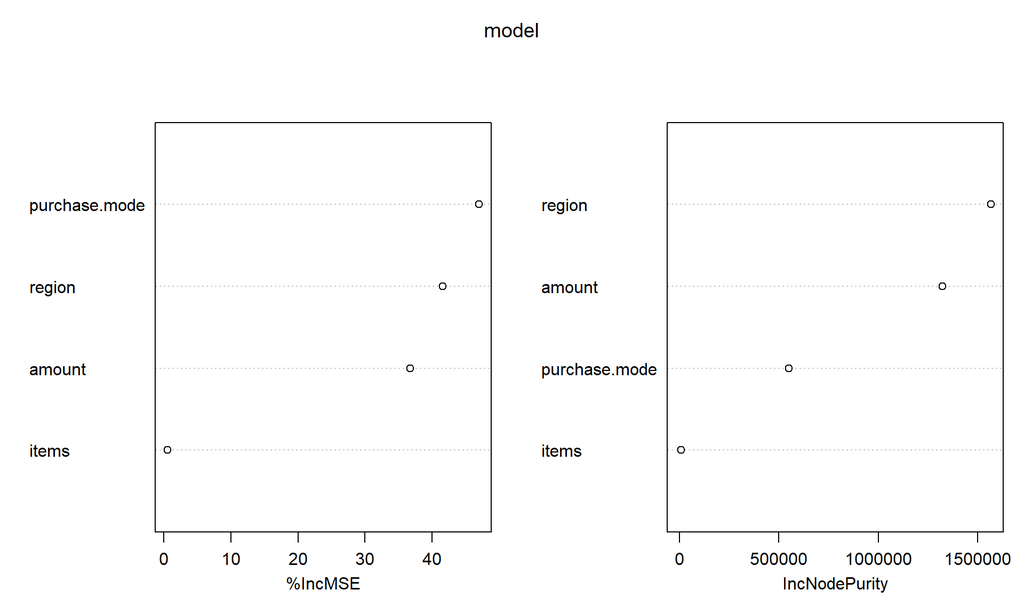

## feature selection

Variable importance analysis suggested purchase mode and region as relatively influential predictors of age, although their predictive power was weak.

# predictive modeling for age

## data splitting for Age

```
##      Resample1
## [1,]         2
## [2,]         3
## [3,]         5
## [4,]         7
## [5,]         8
## [6,]         9
```

## Building the model using Random Forest.

```
## Random Forest
##
## 63986 samples
##     2 predictor
##
## No pre-processing
## Resampling: Bootstrapped (25 reps)
## Summary of sample sizes: 63986, 63986, 63986, 63986, 63986, 63986, ...
## Resampling results across tuning parameters:
##
##   mtry  RMSE      Rsquared   MAE
##   2     14.02573  0.2053342  11.92887
##   3     14.00035  0.2077677  11.91446
##   4     13.99516  0.2083174  11.90924
##
## RMSE was used to select the optimal model using the smallest value.
## The final value used for the model was mtry = 4.
```

```
## Random Forest
##
## 63986 samples
##     2 predictor
##
## No pre-processing
## Resampling: Bootstrapped (25 reps)
## Summary of sample sizes: 63986, 63986, 63986, 63986, 63986, 63986, ...
## Resampling results across tuning parameters:
##
##   mtry  RMSE      Rsquared   MAE
##   2     14.02573  0.2053342  11.92887
##   3     14.00035  0.2077677  11.91446
##   4     13.99516  0.2083174  11.90924
##
## RMSE was used to select the optimal model using the smallest value.
## The final value used for the model was mtry = 4.
```

## Testing the model.

# Predicted

```
##        1        4        6       15       20       21
## 56.70205 48.89080 40.48097 37.01711 40.48097 40.48097
```

# Actual

```
## [1] 37 46 24 34 58 37
```

## Building the model using Pls.

```
## Partial Least Squares
##
## 63986 samples
##     2 predictor
##
## No pre-processing
## Resampling: Cross-Validated (10 fold, repeated 10 times)
## Summary of sample sizes: 57588, 57588, 57587, 57587, 57587, 57587, ...
## Resampling results across tuning parameters:
##
##   ncomp  RMSE      Rsquared   MAE
##   1      14.29758  0.1734304  12.09037
##   2      14.21508  0.1829396  12.05959
##   3      14.18401  0.1865144  12.03760
##
## RMSE was used to select the optimal model using the smallest value.
## The final value used for the model was ncomp = 3.
```

```
## Partial Least Squares
##
## 63986 samples
##     2 predictor
##
## No pre-processing
## Resampling: Cross-Validated (10 fold, repeated 10 times)
## Summary of sample sizes: 57588, 57588, 57587, 57587, 57587, 57587, ...
## Resampling results across tuning parameters:
##
##   ncomp  RMSE      Rsquared   MAE
##   1      14.29758  0.1734304  12.09037
##   2      14.21508  0.1829396  12.05959
##   3      14.18401  0.1865144  12.03760
##
## RMSE was used to select the optimal model using the smallest value.
## The final value used for the model was ncomp = 3.
```

## Testing the model.

# Predicted

```
## [1] 56.54737 44.75237 38.47975 38.69519 38.47975 38.47975
```

# Actual

```
## [1] 37 46 24 34 58 37
```

## Building the model using Linear Model.

```
## Linear Regression
##
## 63986 samples
##     2 predictor
##
## No pre-processing
## Resampling: Cross-Validated (10 fold, repeated 10 times)
## Summary of sample sizes: 57588, 57588, 57587, 57587, 57587, 57587, ...
## Resampling results:
##
##   RMSE     Rsquared   MAE
##   14.1543  0.1899218  12.00775
##
## Tuning parameter 'intercept' was held constant at a value of TRUE
```

```
## Linear Regression
##
## 63986 samples
##     2 predictor
##
## No pre-processing
## Resampling: Cross-Validated (10 fold, repeated 10 times)
## Summary of sample sizes: 57588, 57588, 57587, 57587, 57587, 57587, ...
## Resampling results:
##
##   RMSE     Rsquared   MAE
##   14.1543  0.1899218  12.00775
##
## Tuning parameter 'intercept' was held constant at a value of TRUE
```

## Testing The Model.

# Predicted

```
##        1        4        6       15       20       21
## 56.70235 46.11372 38.13434 39.35730 38.13434 38.13434
```

# Actual

```
## [1] 37 46 24 34 58 37
```

## Scatter Plot for Predicted and Actual

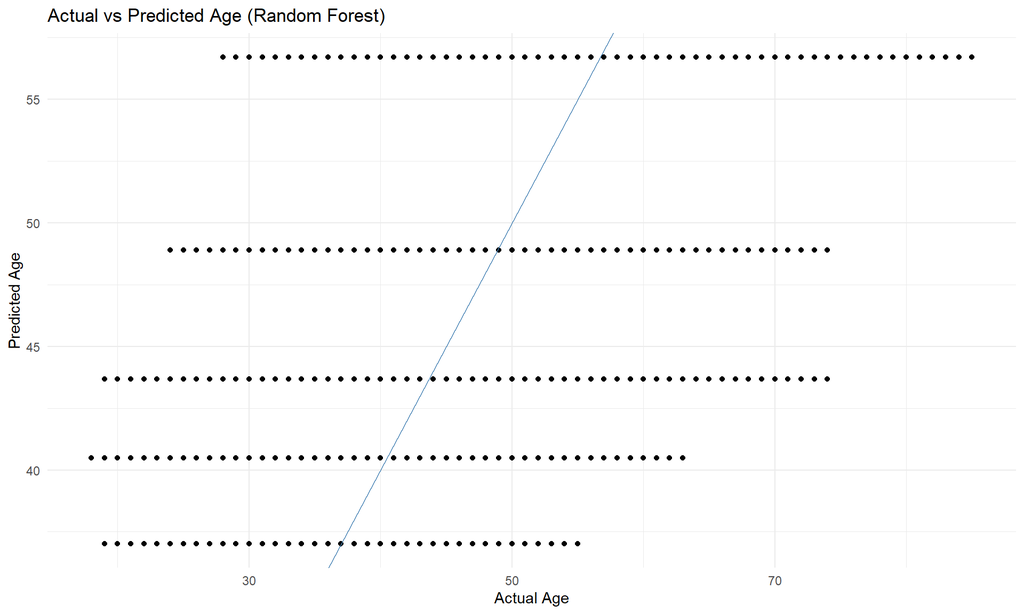

## Key Findings

Random Forest, Partial Least Squares, and Linear Regression models were trained to predict customer age using purchase mode and region as predictors. All models showed low predictive performance (R² ≈ 0.1–0.2), and the scatter plot of actual versus predicted age showed wide dispersion from the 45-degree reference line. This indicates that purchase mode and region have limited predictive power for customer age, suggesting that age is influenced by other unobserved factors such as income, lifestyle, or customer preferences.

# Question 5: Is there a relationship between the age of a customer and if they buy online or in-store

*Type:* Binary Classification Problem

*Target Variable:* Purchase Channel (Online vs In-Store)

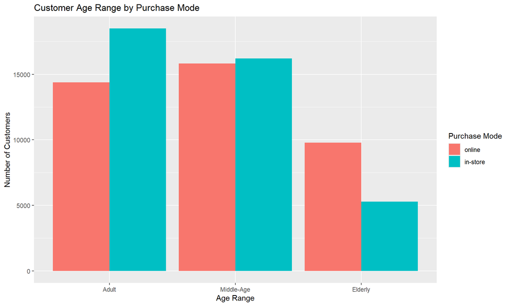

## Key Findings

The bar chart comparing age groups and purchase mode showed that adult and middle-aged customers preferred in-store purchases, while elderly customers showed a relatively higher proportion of online purchases. This contradicts Martin’s hypothesis that older customers prefer in-store shopping. Therefore, the hypothesis is rejected based on the observed data.

# Question 6:do any other factors predict if a customer will buy online or in-store

*What factors predict if customers buy online or in-store?*

## Correlation Matrix

```
##               purchase.mode           age         items        amount
## purchase.mode   1.000000000 -0.1782562201 -0.0039539586 -0.0854743767
## age            -0.178256220  1.0000000000  0.0006785133 -0.2820891185
## items          -0.003953959  0.0006785133  1.0000000000  0.0003670029
## amount         -0.085474377 -0.2820891185  0.0003670029  1.0000000000
## region         -0.133114051 -0.2354457211 -0.0019250756  0.4035037609
##                     region
## purchase.mode -0.133114051
## age           -0.235445721
## items         -0.001925076
## amount         0.403503761
## region         1.000000000
```

## feature selection

Purchase mode predictors are age and region.

## Data splitting for Purchase.mode

```
##      Resample1
## [1,]         3
## [2,]         5
## [3,]         6
## [4,]         7
## [5,]         8
## [6,]        10
```

## Building the model using Gbm Model.

```
## Stochastic Gradient Boosting
##
## 63984 samples
##     2 predictor
##     2 classes: 'online', 'in-store'
##
## No pre-processing
## Resampling: Cross-Validated (10 fold, repeated 10 times)
## Summary of sample sizes: 57586, 57586, 57586, 57586, 57585, 57586, ...
## Resampling results across tuning parameters:
##
##   interaction.depth  n.trees  Accuracy   Kappa
##   1                   50      0.7502032  0.5004065
##   1                  100      0.7537588  0.5075176
##   1                  150      0.7614467  0.5228937
##   2                   50      0.7901382  0.5802764
##   2                  100      0.7924637  0.5849275
##   2                  150      0.7928857  0.5857715
##   3                   50      0.7924575  0.5849150
##   3                  100      0.7928857  0.5857715
##   3                  150      0.7928857  0.5857715
##
## Tuning parameter 'shrinkage' was held constant at a value of 0.1
##
## Tuning parameter 'n.minobsinnode' was held constant at a value of 10
## Accuracy was used to select the optimal model using the largest value.
## The final values used for the model were n.trees = 100, interaction.depth =
##  3, shrinkage = 0.1 and n.minobsinnode = 10.
```

```
## Stochastic Gradient Boosting
##
## 63984 samples
##     2 predictor
##     2 classes: 'online', 'in-store'
##
## No pre-processing
## Resampling: Cross-Validated (10 fold, repeated 10 times)
## Summary of sample sizes: 57586, 57586, 57586, 57586, 57585, 57586, ...
## Resampling results across tuning parameters:
##
##   interaction.depth  n.trees  Accuracy   Kappa
##   1                   50      0.7502032  0.5004065
##   1                  100      0.7537588  0.5075176
##   1                  150      0.7614467  0.5228937
##   2                   50      0.7901382  0.5802764
##   2                  100      0.7924637  0.5849275
##   2                  150      0.7928857  0.5857715
##   3                   50      0.7924575  0.5849150
##   3                  100      0.7928857  0.5857715
##   3                  150      0.7928857  0.5857715
##
## Tuning parameter 'shrinkage' was held constant at a value of 0.1
##
## Tuning parameter 'n.minobsinnode' was held constant at a value of 10
## Accuracy was used to select the optimal model using the largest value.
## The final values used for the model were n.trees = 100, interaction.depth =
##  3, shrinkage = 0.1 and n.minobsinnode = 10.
```

## Predicted

```
## [1] online   online   in-store in-store in-store in-store
## Levels: online in-store
```

## Actual

```
## [1] online   online   in-store in-store in-store in-store
## Levels: online in-store
```

## Building the model using C50 Model

```
## C5.0
##
## 63984 samples
##     2 predictor
##     2 classes: 'online', 'in-store'
##
## No pre-processing
## Resampling: Cross-Validated (10 fold, repeated 10 times)
## Summary of sample sizes: 57586, 57586, 57586, 57586, 57585, 57586, ...
## Resampling results across tuning parameters:
##
##   model  winnow  trials  Accuracy   Kappa
##   rules  FALSE    1      0.7917933  0.5835866
##   rules  FALSE   10      0.7924950  0.5849901
##   rules  FALSE   20      0.7925200  0.5850401
##   rules   TRUE    1      0.7917933  0.5835866
##   rules   TRUE   10      0.7924950  0.5849901
##   rules   TRUE   20      0.7925200  0.5850401
##   tree   FALSE    1      0.7917933  0.5835866
##   tree   FALSE   10      0.7608793  0.5217587
##   tree   FALSE   20      0.7654929  0.5309859
##   tree    TRUE    1      0.7917933  0.5835866
##   tree    TRUE   10      0.7608793  0.5217587
##   tree    TRUE   20      0.7654929  0.5309859
##
## Accuracy was used to select the optimal model using the largest value.
## The final values used for the model were trials = 20, model = rules and
##  winnow = TRUE.
```

```
## C5.0
##
## 63984 samples
##     2 predictor
##     2 classes: 'online', 'in-store'
##
## No pre-processing
## Resampling: Cross-Validated (10 fold, repeated 10 times)
## Summary of sample sizes: 57586, 57586, 57586, 57586, 57585, 57586, ...
## Resampling results across tuning parameters:
##
##   model  winnow  trials  Accuracy   Kappa
##   rules  FALSE    1      0.7917933  0.5835866
##   rules  FALSE   10      0.7924950  0.5849901
##   rules  FALSE   20      0.7925200  0.5850401
##   rules   TRUE    1      0.7917933  0.5835866
##   rules   TRUE   10      0.7924950  0.5849901
##   rules   TRUE   20      0.7925200  0.5850401
##   tree   FALSE    1      0.7917933  0.5835866
##   tree   FALSE   10      0.7608793  0.5217587
##   tree   FALSE   20      0.7654929  0.5309859
##   tree    TRUE    1      0.7917933  0.5835866
##   tree    TRUE   10      0.7608793  0.5217587
##   tree    TRUE   20      0.7654929  0.5309859
##
## Accuracy was used to select the optimal model using the largest value.
## The final values used for the model were trials = 20, model = rules and
##  winnow = TRUE.
```

## Testing My Model.

```
## [1] online   online   in-store in-store in-store in-store
## Levels: online in-store
```

## Actual

```
## [1] online   online   in-store in-store in-store in-store
## Levels: online in-store
```

## Building the model using PLS Model

```
## Partial Least Squares
##
## 63984 samples
##     2 predictor
##     2 classes: 'online', 'in-store'
##
## No pre-processing
## Resampling: Cross-Validated (10 fold, repeated 10 times)
## Summary of sample sizes: 57586, 57586, 57586, 57586, 57585, 57586, ...
## Resampling results across tuning parameters:
##
##   ncomp  Accuracy   Kappa
##   1      0.5627501  0.1255002
##   2      0.7502032  0.5004065
##   3      0.7502188  0.5004377
##
## Accuracy was used to select the optimal model using the largest value.
## The final value used for the model was ncomp = 3.
```

```
## Partial Least Squares
##
## 63984 samples
##     2 predictor
##     2 classes: 'online', 'in-store'
##
## No pre-processing
## Resampling: Cross-Validated (10 fold, repeated 10 times)
## Summary of sample sizes: 57586, 57586, 57586, 57586, 57585, 57586, ...
## Resampling results across tuning parameters:
##
##   ncomp  Accuracy   Kappa
##   1      0.5627501  0.1255002
##   2      0.7502032  0.5004065
##   3      0.7502188  0.5004377
##
## Accuracy was used to select the optimal model using the largest value.
## The final value used for the model was ncomp = 3.
```

## Testing My Model

```
## [1] online   online   in-store in-store in-store in-store
## Levels: online in-store
```

## Actual

```
## [1] online   online   in-store in-store in-store in-store
## Levels: online in-store
```

# confusion matrix for my prediction for purchase mode.

## Gbm

```
## Confusion Matrix and Statistics
##
##           Reference
## Prediction online in-store
##   online     4767       94
##   in-store   3230     7904
##
##                Accuracy : 0.7922
##                  95% CI : (0.7858, 0.7985)
##     No Information Rate : 0.5
##     P-Value [Acc > NIR] : < 2.2e-16
##
##                   Kappa : 0.5844
##
##  Mcnemar's Test P-Value : < 2.2e-16
##
##             Sensitivity : 0.5961
##             Specificity : 0.9882
##          Pos Pred Value : 0.9807
##          Neg Pred Value : 0.7099
##              Prevalence : 0.5000
##          Detection Rate : 0.2980
##    Detection Prevalence : 0.3039
##       Balanced Accuracy : 0.7922
##
##        'Positive' Class : online
##
```

## C50

```
## Confusion Matrix and Statistics
##
##           Reference
## Prediction online in-store
##   online     4737       78
##   in-store   3260     7920
##
##                Accuracy : 0.7913
##                  95% CI : (0.7849, 0.7976)
##     No Information Rate : 0.5
##     P-Value [Acc > NIR] : < 2.2e-16
##
##                   Kappa : 0.5826
##
##  Mcnemar's Test P-Value : < 2.2e-16
##
##             Sensitivity : 0.5923
##             Specificity : 0.9902
##          Pos Pred Value : 0.9838
##          Neg Pred Value : 0.7084
##              Prevalence : 0.5000
##          Detection Rate : 0.2962
##    Detection Prevalence : 0.3010
##       Balanced Accuracy : 0.7913
##
##        'Positive' Class : online
##
```

## PLS

```
## Confusion Matrix and Statistics
##
##           Reference
## Prediction online in-store
##   online     3985        0
##   in-store   4012     7998
##
##                Accuracy : 0.7492
##                  95% CI : (0.7424, 0.7559)
##     No Information Rate : 0.5
##     P-Value [Acc > NIR] : < 2.2e-16
##
##                   Kappa : 0.4983
##
##  Mcnemar's Test P-Value : < 2.2e-16
##
##             Sensitivity : 0.4983
##             Specificity : 1.0000
##          Pos Pred Value : 1.0000
##          Neg Pred Value : 0.6659
##              Prevalence : 0.5000
##          Detection Rate : 0.2491
##    Detection Prevalence : 0.2491
##       Balanced Accuracy : 0.7492
##
##        'Positive' Class : online
##
```

## Final Model Using GBM

```
## Stochastic Gradient Boosting
##
## 63984 samples
##     2 predictor
##     2 classes: 'online', 'in-store'
##
## No pre-processing
## Resampling: Cross-Validated (10 fold, repeated 10 times)
## Summary of sample sizes: 57586, 57586, 57586, 57586, 57585, 57586, ...
## Resampling results:
##
##   Accuracy   Kappa
##   0.7928857  0.5857715
##
## Tuning parameter 'n.trees' was held constant at a value of 100
## Tuning
##
## Tuning parameter 'shrinkage' was held constant at a value of 0.1
##
## Tuning parameter 'n.minobsinnode' was held constant at a value of 10
```

```
## Stochastic Gradient Boosting
##
## 63984 samples
##     2 predictor
##     2 classes: 'online', 'in-store'
##
## No pre-processing
## Resampling: Cross-Validated (10 fold, repeated 10 times)
## Summary of sample sizes: 57586, 57586, 57586, 57586, 57585, 57586, ...
## Resampling results:
##
##   Accuracy   Kappa
##   0.7928857  0.5857715
##
## Tuning parameter 'n.trees' was held constant at a value of 100
## Tuning
##
## Tuning parameter 'shrinkage' was held constant at a value of 0.1
##
## Tuning parameter 'n.minobsinnode' was held constant at a value of 10
```

## Final Prediction

```
## [1] online   online   in-store in-store in-store in-store
## Levels: online in-store
```

## Actual

```
## [1] online   online   in-store in-store in-store in-store
## Levels: online in-store
```

## Key Findings

Classification models (GBM, C5.0, and PLS) were trained to predict purchase mode using age and region. The GBM model achieved the highest accuracy and was selected as the final model. The results indicate that age and region moderately predict whether a customer will purchase online or in-store, demonstrating that demographic factors influence purchasing channel preference.

# Question 7:can we predict the region of a customer using other demographics.

*Can we predict which region a customer is from?*

*Type:* Multi-Class Classification Problem (4 classes)

*Target Variable:* Region (North, South, East, West)

*Predictors:* Age, Purchase Channel, Amount

## data splitting for Region

```
##      Resample1
## [1,]         1
## [2,]         3
## [3,]         5
## [4,]         7
## [5,]         9
## [6,]        10
```

## Building My Model Using GBM

```
## Stochastic Gradient Boosting
##
## 63985 samples
##     3 predictor
##     4 classes: 'North', 'South', 'East', 'West'
##
## No pre-processing
## Resampling: Cross-Validated (10 fold, repeated 10 times)
## Summary of sample sizes: 57586, 57587, 57588, 57586, 57587, 57587, ...
## Resampling results across tuning parameters:
##
##   interaction.depth  n.trees  Accuracy   Kappa
##   1                   50      0.6278096  0.4988610
##   1                  100      0.6330968  0.5054392
##   1                  150      0.6338673  0.5064104
##   2                   50      0.6402922  0.5134161
##   2                  100      0.6413253  0.5146794
##   2                  150      0.6416613  0.5150827
##   3                   50      0.6431101  0.5167856
##   3                  100      0.6432070  0.5168535
##   3                  150      0.6432351  0.5167880
##
## Tuning parameter 'shrinkage' was held constant at a value of 0.1
##
## Tuning parameter 'n.minobsinnode' was held constant at a value of 10
## Accuracy was used to select the optimal model using the largest value.
## The final values used for the model were n.trees = 150, interaction.depth =
##  3, shrinkage = 0.1 and n.minobsinnode = 10.
```

```
## Stochastic Gradient Boosting
##
## 63985 samples
##     3 predictor
##     4 classes: 'North', 'South', 'East', 'West'
##
## No pre-processing
## Resampling: Cross-Validated (10 fold, repeated 10 times)
## Summary of sample sizes: 57586, 57587, 57588, 57586, 57587, 57587, ...
## Resampling results across tuning parameters:
##
##   interaction.depth  n.trees  Accuracy   Kappa
##   1                   50      0.6278096  0.4988610
##   1                  100      0.6330968  0.5054392
##   1                  150      0.6338673  0.5064104
##   2                   50      0.6402922  0.5134161
##   2                  100      0.6413253  0.5146794
##   2                  150      0.6416613  0.5150827
##   3                   50      0.6431101  0.5167856
##   3                  100      0.6432070  0.5168535
##   3                  150      0.6432351  0.5167880
##
## Tuning parameter 'shrinkage' was held constant at a value of 0.1
##
## Tuning parameter 'n.minobsinnode' was held constant at a value of 10
## Accuracy was used to select the optimal model using the largest value.
## The final values used for the model were n.trees = 150, interaction.depth =
##  3, shrinkage = 0.1 and n.minobsinnode = 10.
```

## Testing My GBM Model

```
## [1] South North West  East  North North
## Levels: North South East West
```

## Actual

```
## [1] South East  West  East  West  East
## Levels: North South East West
```

## Building My Model Using GLM

```
## glmnet
##
## 63985 samples
##     3 predictor
##     4 classes: 'North', 'South', 'East', 'West'
##
## No pre-processing
## Resampling: Cross-Validated (10 fold, repeated 10 times)
## Summary of sample sizes: 57586, 57587, 57588, 57586, 57587, 57587, ...
## Resampling results across tuning parameters:
##
##   alpha  lambda        Accuracy   Kappa
##   0.10   0.0005000625  0.6101117  0.4750369
##   0.10   0.0050006252  0.6106838  0.4748854
##   0.10   0.0500062518  0.6072064  0.4675773
##   0.55   0.0005000625  0.6098460  0.4747111
##   0.55   0.0050006252  0.6105556  0.4745534
##   0.55   0.0500062518  0.6027131  0.4604483
##   1.00   0.0005000625  0.6095569  0.4743373
##   1.00   0.0050006252  0.6121075  0.4763388
##   1.00   0.0500062518  0.5993670  0.4549862
##
## Accuracy was used to select the optimal model using the largest value.
## The final values used for the model were alpha = 1 and lambda = 0.005000625.
```

```
## glmnet
##
## 63985 samples
##     3 predictor
##     4 classes: 'North', 'South', 'East', 'West'
##
## No pre-processing
## Resampling: Cross-Validated (10 fold, repeated 10 times)
## Summary of sample sizes: 57586, 57587, 57588, 57586, 57587, 57587, ...
## Resampling results across tuning parameters:
##
##   alpha  lambda        Accuracy   Kappa
##   0.10   0.0005000625  0.6101117  0.4750369
##   0.10   0.0050006252  0.6106838  0.4748854
##   0.10   0.0500062518  0.6072064  0.4675773
##   0.55   0.0005000625  0.6098460  0.4747111
##   0.55   0.0050006252  0.6105556  0.4745534
##   0.55   0.0500062518  0.6027131  0.4604483
##   1.00   0.0005000625  0.6095569  0.4743373
##   1.00   0.0050006252  0.6121075  0.4763388
##   1.00   0.0500062518  0.5993670  0.4549862
##
## Accuracy was used to select the optimal model using the largest value.
## The final values used for the model were alpha = 1 and lambda = 0.005000625.
```

## Testing My Model

```
## [1] South North West  North North North
## Levels: North South East West
```

## Actual

```
## [1] South East  West  East  West  East
## Levels: North South East West
```

## Building My Model Using C50

```
## C5.0
##
## 63985 samples
##     3 predictor
##     4 classes: 'North', 'South', 'East', 'West'
##
## No pre-processing
## Resampling: Cross-Validated (10 fold, repeated 10 times)
## Summary of sample sizes: 57586, 57587, 57588, 57586, 57587, 57587, ...
## Resampling results across tuning parameters:
##
##   model  winnow  trials  Accuracy   Kappa
##   rules  FALSE    1      0.6457513  0.5201620
##   rules  FALSE   10      0.6381995  0.5107158
##   rules  FALSE   20      0.6384714  0.5110249
##   rules   TRUE    1      0.6457513  0.5201620
##   rules   TRUE   10      0.6381995  0.5107158
##   rules   TRUE   20      0.6384714  0.5110249
##   tree   FALSE    1      0.6457513  0.5201620
##   tree   FALSE   10      0.6406360  0.5136188
##   tree   FALSE   20      0.6405892  0.5135362
##   tree    TRUE    1      0.6457513  0.5201620
##   tree    TRUE   10      0.6406360  0.5136188
##   tree    TRUE   20      0.6405892  0.5135362
##
## Accuracy was used to select the optimal model using the largest value.
## The final values used for the model were trials = 1, model = rules and winnow
##  = TRUE.
```

```
## C5.0
##
## 63985 samples
##     3 predictor
##     4 classes: 'North', 'South', 'East', 'West'
##
## No pre-processing
## Resampling: Cross-Validated (10 fold, repeated 10 times)
## Summary of sample sizes: 57586, 57587, 57588, 57586, 57587, 57587, ...
## Resampling results across tuning parameters:
##
##   model  winnow  trials  Accuracy   Kappa
##   rules  FALSE    1      0.6457513  0.5201620
##   rules  FALSE   10      0.6381995  0.5107158
##   rules  FALSE   20      0.6384714  0.5110249
##   rules   TRUE    1      0.6457513  0.5201620
##   rules   TRUE   10      0.6381995  0.5107158
##   rules   TRUE   20      0.6384714  0.5110249
##   tree   FALSE    1      0.6457513  0.5201620
##   tree   FALSE   10      0.6406360  0.5136188
##   tree   FALSE   20      0.6405892  0.5135362
##   tree    TRUE    1      0.6457513  0.5201620
##   tree    TRUE   10      0.6406360  0.5136188
##   tree    TRUE   20      0.6405892  0.5135362
##
## Accuracy was used to select the optimal model using the largest value.
## The final values used for the model were trials = 1, model = rules and winnow
##  = TRUE.
```

# Testing My model

```
## [1] South North West  East  North North
## Levels: North South East West
```

# Actual

```
## [1] South East  West  East  West  East
## Levels: North South East West
```

# confusion matrix for Region prediction

```
## Confusion Matrix and Statistics
##
##           Reference
## Prediction North South East West
##      North  1702     0 1417 1081
##      South     0  3998  140  283
##      East    607     0  792  102
##      West    890     0 1251 3731
##
## Overall Statistics
##
##                Accuracy : 0.6392
##                  95% CI : (0.6317, 0.6466)
##     No Information Rate : 0.3249
##     P-Value [Acc > NIR] : < 2.2e-16
##
##                   Kappa : 0.5111
##
##  Mcnemar's Test P-Value : NA
##
## Statistics by Class:
##
##                      Class: North Class: South Class: East Class: West
## Sensitivity                0.5320       1.0000     0.22000      0.7179
## Specificity                0.8048       0.9647     0.94279      0.8017
## Pos Pred Value             0.4052       0.9043     0.52765      0.6354
## Neg Pred Value             0.8731       1.0000     0.80625      0.8552
## Prevalence                 0.2000       0.2500     0.22508      0.3249
## Detection Rate             0.1064       0.2500     0.04952      0.2333
## Detection Prevalence       0.2626       0.2764     0.09385      0.3671
## Balanced Accuracy          0.6684       0.9824     0.58140      0.7598
```

## GLM

```
## Confusion Matrix and Statistics
##
##           Reference
## Prediction North South East West
##      North  2189     0 1975 1172
##      South     0  3992  238  458
##      East      0     0   70  133
##      West   1010     6 1317 3434
##
## Overall Statistics
##
##                Accuracy : 0.6055
##                  95% CI : (0.5979, 0.6131)
##     No Information Rate : 0.3249
##     P-Value [Acc > NIR] : < 2.2e-16
##
##                   Kappa : 0.4669
##
##  Mcnemar's Test P-Value : NA
##
## Statistics by Class:
##
##                      Class: North Class: South Class: East Class: West
## Sensitivity                0.6843       0.9985    0.019444      0.6608
## Specificity                0.7540       0.9420    0.989269      0.7839
## Pos Pred Value             0.4102       0.8515    0.344828      0.5955
## Neg Pred Value             0.9052       0.9995    0.776455      0.8276
## Prevalence                 0.2000       0.2500    0.225084      0.3249
## Detection Rate             0.1369       0.2496    0.004377      0.2147
## Detection Prevalence       0.3336       0.2931    0.012692      0.3606
## Balanced Accuracy          0.7192       0.9702    0.504357      0.7223
```

## C50

```
## Confusion Matrix and Statistics
##
##           Reference
## Prediction North South East West
##      North  1715     0 1419 1137
##      South     0  3998  140  283
##      East    634     0  777    0
##      West    850     0 1264 3777
##
## Overall Statistics
##
##                Accuracy : 0.6419
##                  95% CI : (0.6344, 0.6494)
##     No Information Rate : 0.3249
##     P-Value [Acc > NIR] : < 2.2e-16
##
##                   Kappa : 0.5148
##
##  Mcnemar's Test P-Value : NA
##
## Statistics by Class:
##
##                      Class: North Class: South Class: East Class: West
## Sensitivity                0.5361       1.0000     0.21583      0.7268
## Specificity                0.8002       0.9647     0.94885      0.8042
## Pos Pred Value             0.4015       0.9043     0.55067      0.6411
## Neg Pred Value             0.8734       1.0000     0.80642      0.8594
## Prevalence                 0.2000       0.2500     0.22508      0.3249
## Detection Rate             0.1072       0.2500     0.04858      0.2362
## Detection Prevalence       0.2670       0.2764     0.08822      0.3683
## Balanced Accuracy          0.6682       0.9824     0.58234      0.7655
```

## Final Model Using GBM

```
## Stochastic Gradient Boosting
##
## 63985 samples
##     3 predictor
##     4 classes: 'North', 'South', 'East', 'West'
##
## No pre-processing
## Resampling: Cross-Validated (10 fold, repeated 10 times)
## Summary of sample sizes: 57586, 57587, 57588, 57586, 57587, 57587, ...
## Resampling results:
##
##   Accuracy   Kappa
##   0.6433914  0.5169711
##
## Tuning parameter 'n.trees' was held constant at a value of 150
## Tuning
##
## Tuning parameter 'shrinkage' was held constant at a value of 0.1
##
## Tuning parameter 'n.minobsinnode' was held constant at a value of 10
```

```
## Stochastic Gradient Boosting
##
## 63985 samples
##     3 predictor
##     4 classes: 'North', 'South', 'East', 'West'
##
## No pre-processing
## Resampling: Cross-Validated (10 fold, repeated 10 times)
## Summary of sample sizes: 57586, 57587, 57588, 57586, 57587, 57587, ...
## Resampling results:
##
##   Accuracy   Kappa
##   0.6433914  0.5169711
##
## Tuning parameter 'n.trees' was held constant at a value of 150
## Tuning
##
## Tuning parameter 'shrinkage' was held constant at a value of 0.1
##
## Tuning parameter 'n.minobsinnode' was held constant at a value of 10
```

## Predicted

```
## [1] South North West  East  North North
## Levels: North South East West
```

## Actual

```
## [1] South East  West  East  West  East
## Levels: North South East West
```

# Conclusion

This study investigated customer purchasing patterns in Blackwell’s e-commerce transactions, focusing on regional spending behavior, relationships between items purchased and transaction amount, and predictive modeling of demographic and behavioral variables.

Correlation and regression analyses showed that demographic variables such as region and purchase mode had limited predictive power for customer age, indicating that age is influenced by factors beyond the variables available in this dataset. However, classification models demonstrated that age and region can moderately predict purchase mode, and demographic and behavioral variables can also predict customer region with reasonable accuracy.

Overall, the findings highlight the importance of regional and demographic segmentation in understanding customer purchasing behavior. These insights can support targeted marketing strategies and improved customer engagement across online and in-store channels.

# Recommendations

```
1.  Blackwell should increase targeted online marketing campaigns for elderly customers, who show a higher propensity for online purchases.
2.  The company should improve website usability and accessibility to encourage more online transactions among all age groups.
3.  Regional spending insights should be used to design region-specific promotions and pricing strategies to maximize revenue.
4.  Additional customer attributes such as income level, education, and loyalty membership should be collected to improve predictive modeling accuracy.
```